# US commercial flights analysis - Summary report

# Introduction

Analyzig the data from **Research and Innovative Technology Administration (RITA)** we were able to answer the following questions:

1. **How is the trend of commercial flights in the US?**
2. **Which is the best (worst) day of the week to take a flight?**
3. **Which is the best (worst) season to flight in terms of delay?**

# Results

The insight we found are:

1. The trend of commercial flights in the USA as a number of flights seems **to grow** year by year, even though in a non-linear way.

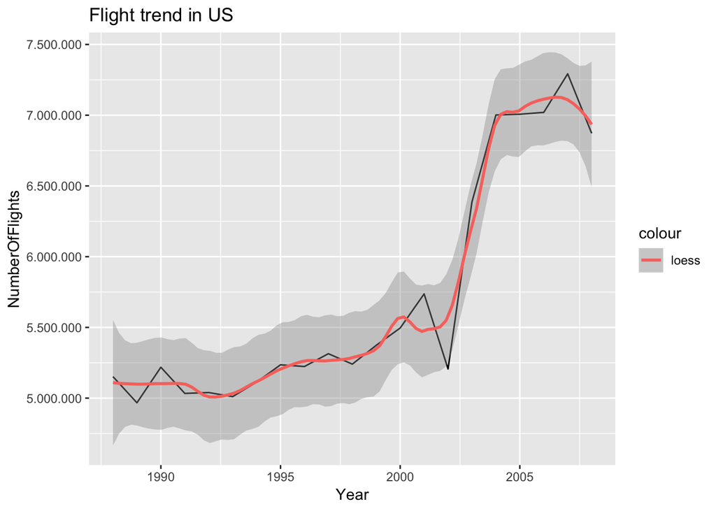

2. The best day of the week to fly which minimize the probability of having a dalayed flight is **Saturday** with an average of percentage of delayed flights that moves from 30% to 52%. The warse day of the week are both **Friday** and **Thursday** with an avareges of percentage of delayed flights that moves respectively between 40% and 62% (Friday) and 39% and 63% (Thursday).

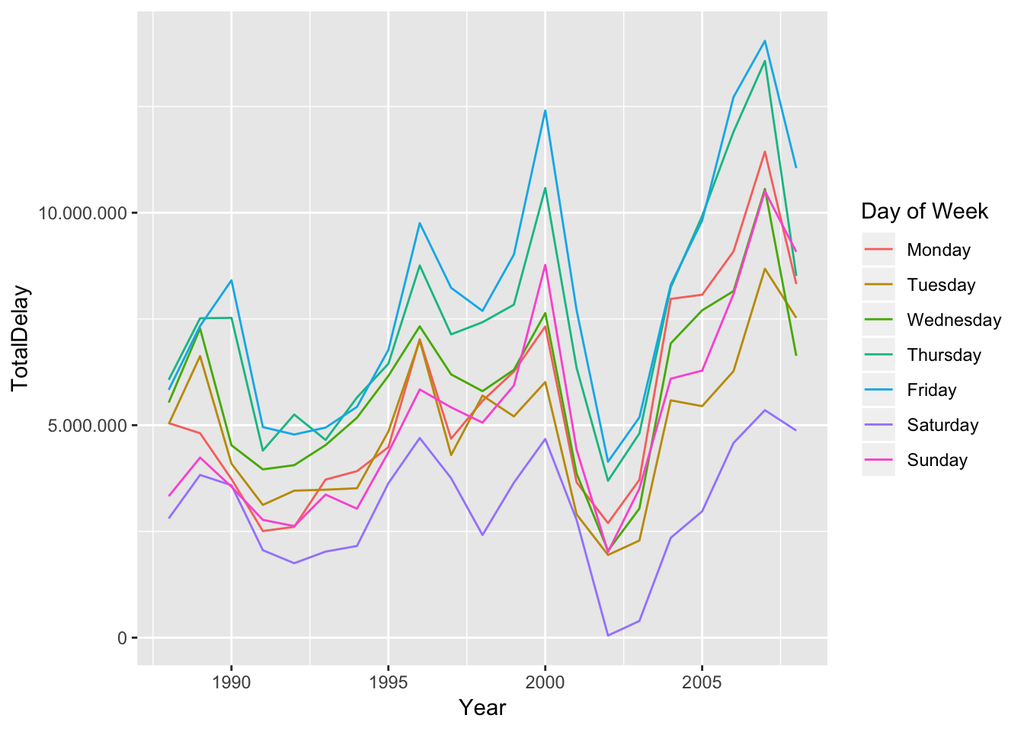

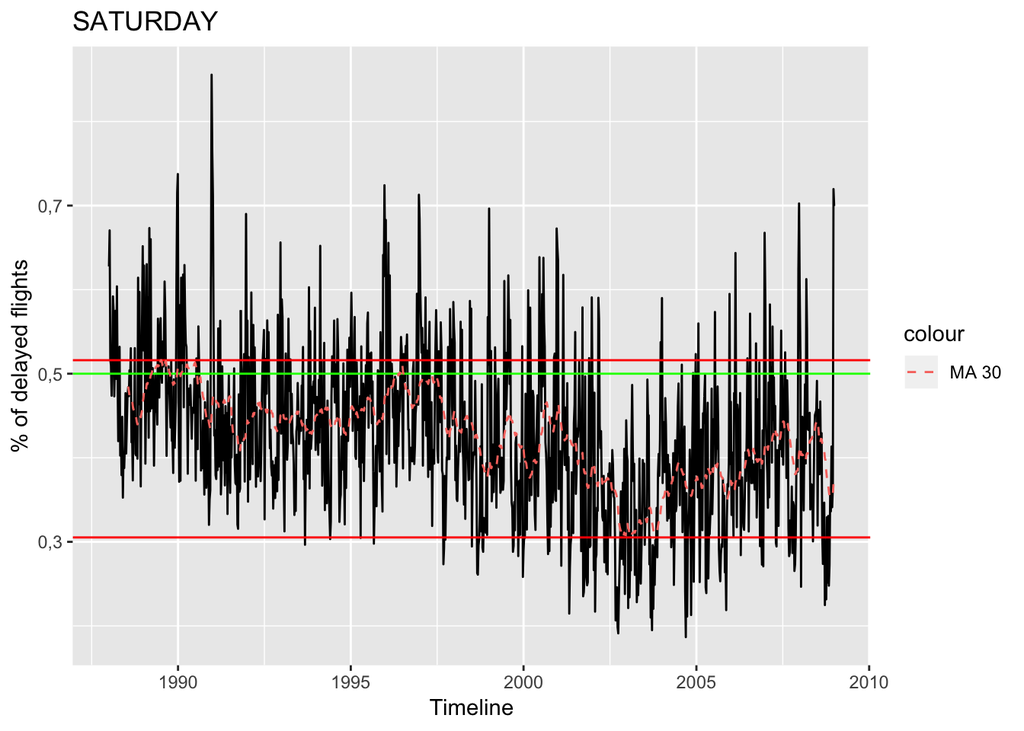

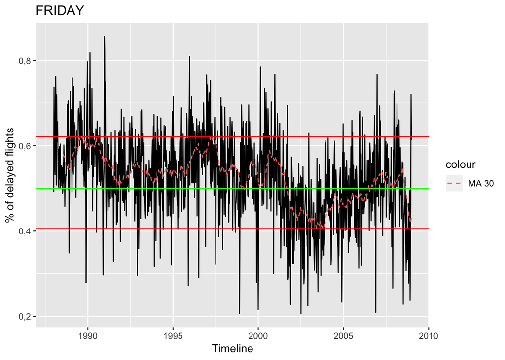

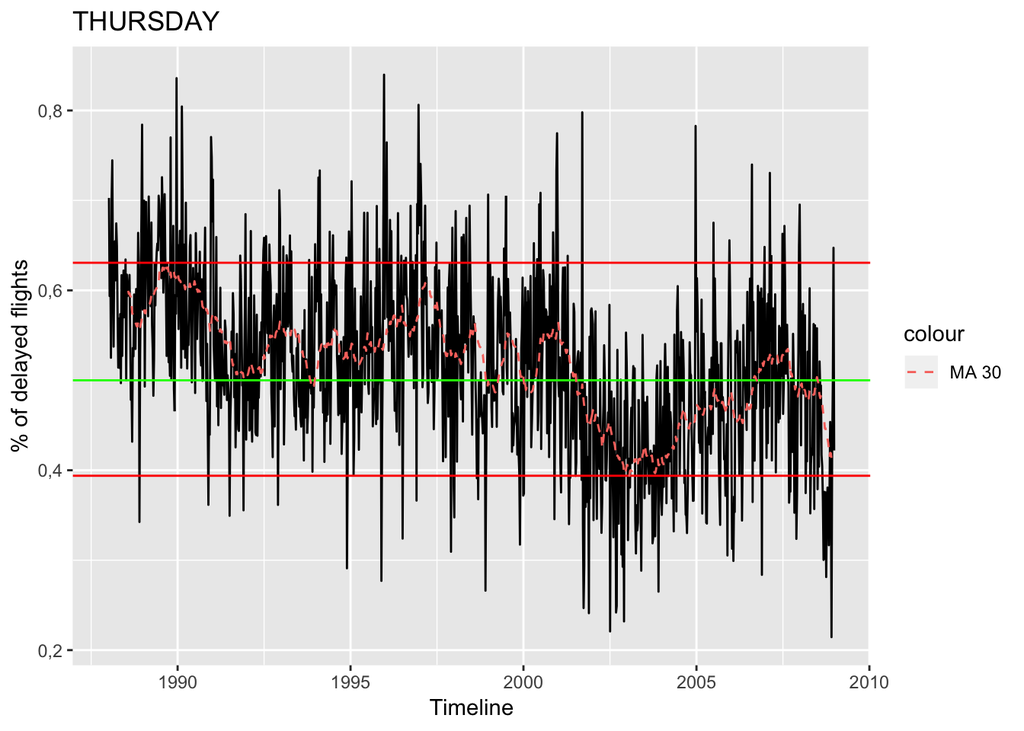

3. The best season to fly to minimize the probability of having a dalayed flight is **Fall** with an average of percentage of delayed flights that goes from 29% to 57%. The worst seasons, instead, are **Summer** and **Winter** with an avareges of percentage of delayed flights that moves respectively between 36% and 63% (Summer) and 33% and 66% (Winter).

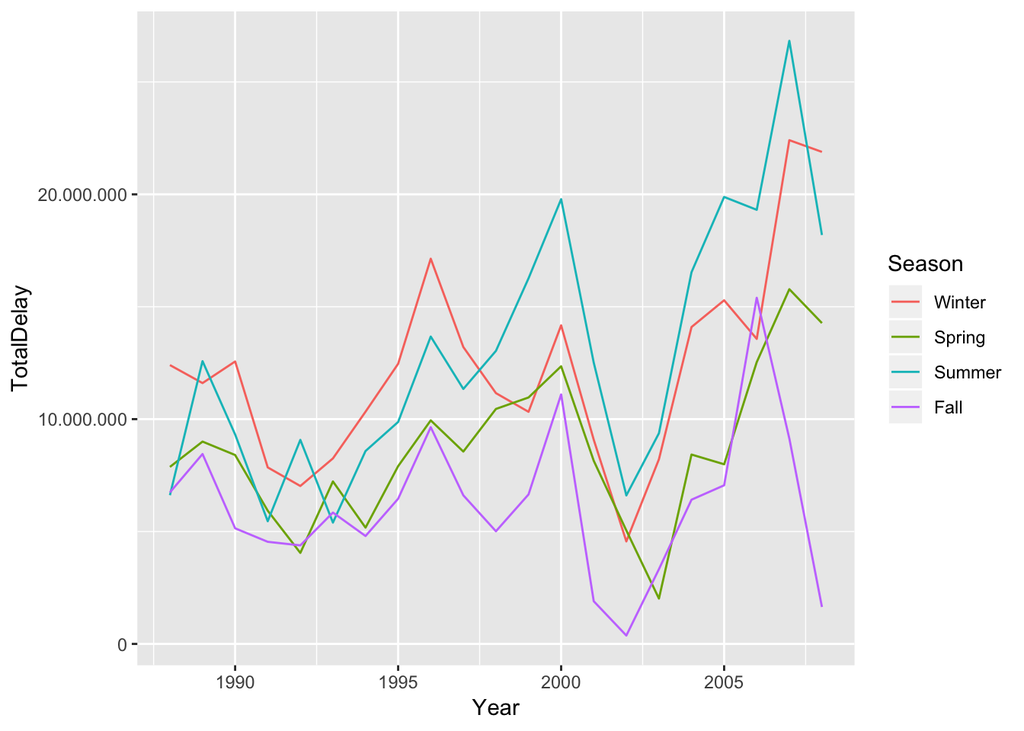

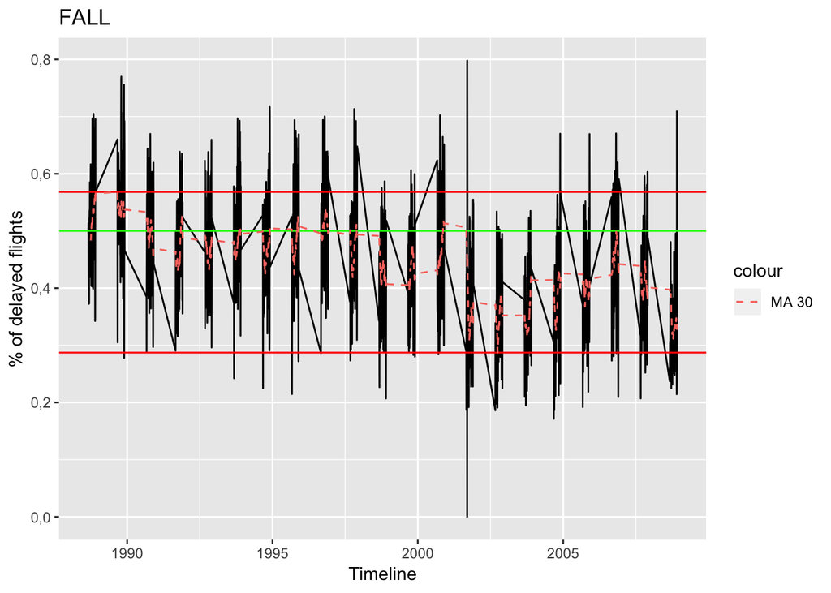

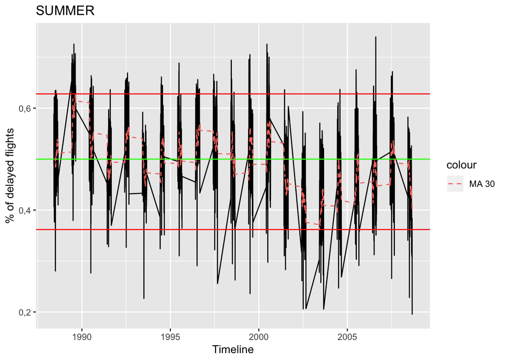

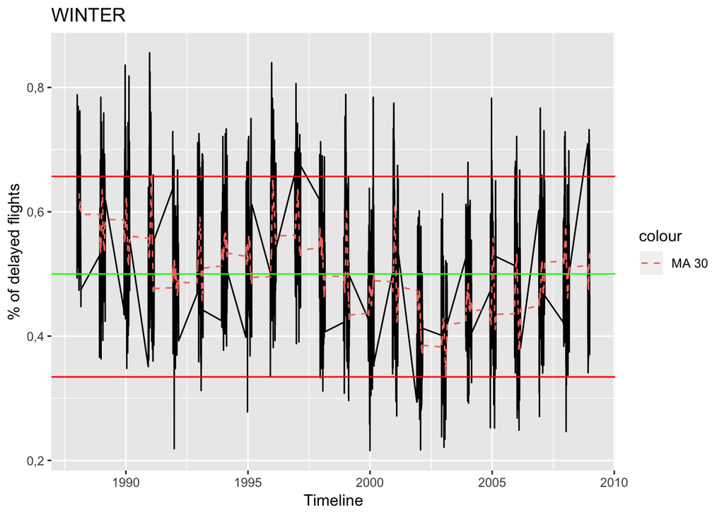